# Life expectancy_Sumeet

**Data Analysis for Life Expectancy in Different Countries**

*By: Sumeet*

**Introduction**

Life expectancy at birth indicates the number of years a newborn infant would live if prevailing patterns of mortality at the time of its birth were to stay the same throughout its life. (United Nations Population Division)

**About the Dataset**

Source: https://www.kaggle.com/datasets

Number of Variables: 18

Number of Countries: 178

Number of Years: 16

```python
import numpy as np
import pandas as pd
import matplotlib.pyplot as plt
import seaborn as sns

data= pd.read_csv("life_expectancy.csv")

print(data.head())

print(data.describe())

print(data.isnull().sum())

data.fillna(method='ffill', inplace=True)

print(data.isnull().sum())


data.columns = data.columns.str.strip()

life_expectancy_upper_limit = data['Life expectancy'].quantile(0.99)
data.loc[data['Life expectancy'] > life_expectancy_upper_limit, 'Life expectancy'] = life_expectancy_upper_limit

duplicates = data.duplicated().sum()
print('Number of duplicate values = ',duplicates)

# Create a new variable for GDP per capita
data['GDP_per_capita'] = data['GDP'] / data['Population']
```

```
       Country  Year      Status  Population  Hepatitis B  Measles  Polio  \
0  Afghanistan  2015  Developing  33736494.0         65.0     1154    6.0
1  Afghanistan  2014  Developing    327582.0         62.0      492   58.0
2  Afghanistan  2013  Developing  31731688.0         64.0      430   62.0
3  Afghanistan  2012  Developing   3696958.0         67.0     2787   67.0
4  Afghanistan  2011  Developing   2978599.0         68.0     3013   68.0

   Diphtheria  HIV/AIDS  infant deaths  under-five deaths  Total expenditure  \
0        65.0       0.1             62                 83               8.16
1        62.0       0.1             64                 86               8.18
2        64.0       0.1             66                 89               8.13
3        67.0       0.1             69                 93               8.52
4        68.0       0.1             71                 97               7.87

          GDP   BMI  thinness  1-19 years  Alcohol  Schooling  Life expectancy
0  584.259210  19.1                  17.2     0.01       10.1             65.0
1  612.696514  18.6                  17.5     0.01       10.0             59.9
2  631.744976  18.1                  17.7     0.01        9.9             59.9
3  669.959000  17.6                  17.9     0.01        9.8             59.5
4   63.537231  17.2                  18.2     0.01        9.5             59.2
              Year    Population  Hepatitis B        Measles        Polio  \
count  2848.000000  2.204000e+03  2306.000000    2848.000000  2829.000000
mean   2007.500000  1.283457e+07    81.076756    2083.082163    82.682220
std       4.610582  6.196094e+07    25.019068   10249.107207    23.434954
min    2000.000000  3.400000e+01     1.000000       0.000000     3.000000
25%    2003.750000  1.967585e+05    77.000000       0.000000    78.000000
50%    2007.500000  1.391756e+06    92.000000      16.000000    93.000000
75%    2011.250000  7.438947e+06    97.000000     336.750000    97.000000
max    2015.000000  1.293859e+09    99.000000  212183.000000    99.000000

        Diphtheria     HIV/AIDS  infant deaths  under-five deaths  \
count  2829.000000  2848.000000    2848.000000        2848.000000
mean     82.451396     1.756461      28.359902          39.500000
std      23.693936     5.148935     117.188032         159.800866
min       2.000000     0.100000       0.000000           0.000000
25%      78.000000     0.100000       0.000000           0.000000
50%      93.000000     0.100000       3.000000           4.000000
75%      97.000000     0.700000      20.000000          25.000000
max      99.000000    50.600000    1800.000000        2500.000000

```

[output cut: 43 more lines]

```
Measles                 0
Polio                   0
Diphtheria              0
HIV/AIDS                0
infant deaths           0
under-five deaths       0
Total expenditure       0
GDP                     0
BMI                     0
thinness  1-19 years    0
Alcohol                 0
Schooling               0
Life expectancy         0
dtype: int64
Number of duplicate values =  0
```

**Data Wrangling Operation**

Examined all the empty entries, applied the Fillna technique to replace the absent data.

Checked for all the Null Values before and After the Fillna technique.

Verified for any replicated data

Eliminated extreme values from the life expectancy variable

Introduced an additional column named GDP per capita, derived from the division of GDP by the overall population count.

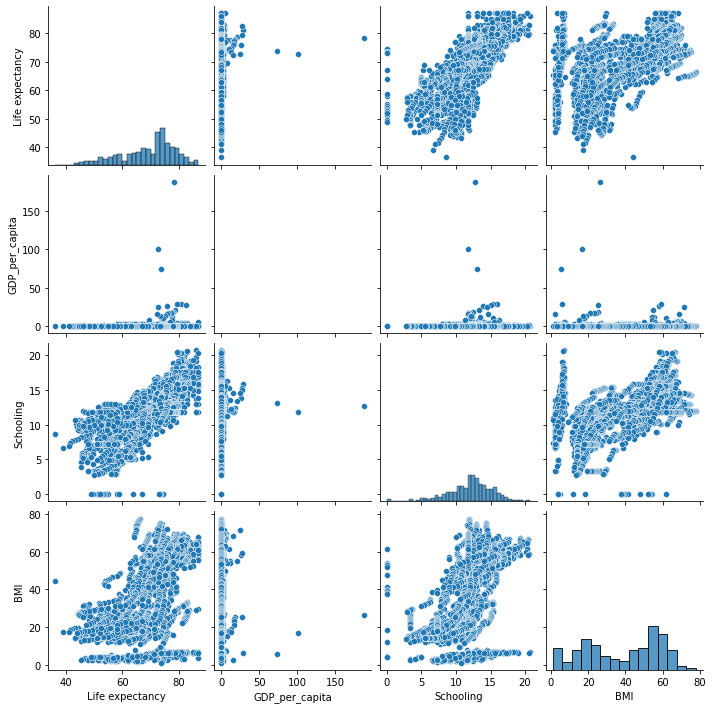

```python
# Pairplot to visualize relationships between numeric variables
sns.pairplot(data, vars=['Life expectancy', 'GDP_per_capita', 'Schooling', 'BMI'])
plt.show()
```

**Pair Plot**

The pair plot is a visual tool that helps us understand the relationships between four key factors: Life Expectancy, GDP per Capita (which is a new measure we are using), Schooling, and BMI (Body Mass Index). It shows how each of these factors is related to one another, making it easier to see patterns and connections.

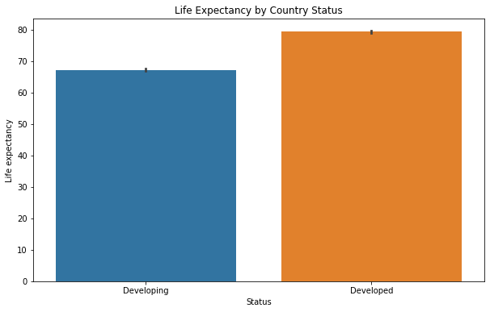

```python
# Bar plot to compare life expectancy by country status
plt.figure(figsize=(10, 6))
sns.barplot(x='Status', y='Life expectancy', data=data)
plt.title('Life Expectancy by Country Status')
plt.show()
```

**Bar Plot**

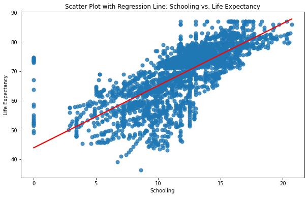

```python
plt.figure(figsize=(10, 6))
sns.regplot(x='Schooling', y='Life expectancy', data=data, scatter_kws={'s': 50}, ci=None, line_kws={'color': 'red'})
plt.xlabel('Schooling')
plt.ylabel('Life Expectancy')
plt.title('Scatter Plot with Regression Line: Schooling vs. Life Expectancy')
plt.show()
```

**Scatter Plot**

The scatter plot illustrates the connection between the number of years of schooling and life expectancy. It shows a positive trend, meaning that as the number of years of schooling increases, life expectancy tends to increase as well.

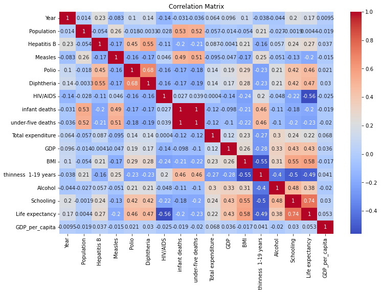

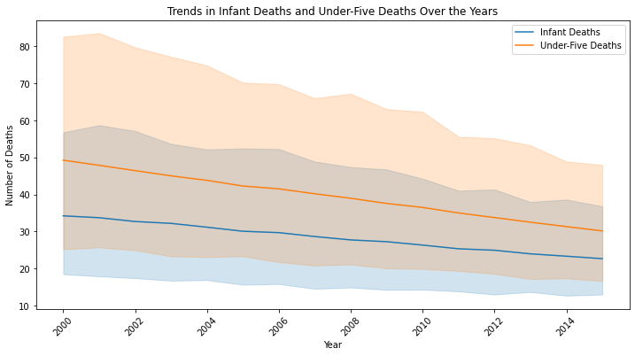

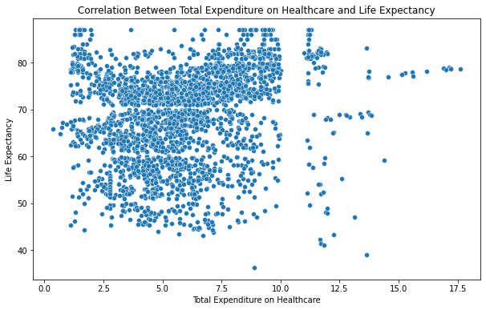

```python
# Question 2: Correlation between life expectancy and other factors
correlation_matrix = data.corr()
plt.figure(figsize=(12, 8))
sns.heatmap(correlation_matrix, annot=True, cmap='coolwarm')
plt.title('Correlation Matrix')
plt.show()

# Question 3: Trends in infant deaths and under-five deaths over the years
plt.figure(figsize=(12, 6))
sns.lineplot(x='Year', y='infant deaths', label='Infant Deaths', data=data)
sns.lineplot(x='Year', y='under-five deaths', label='Under-Five Deaths', data=data)
plt.title('Trends in Infant Deaths and Under-Five Deaths Over the Years')
plt.xlabel('Year')
plt.ylabel('Number of Deaths')
plt.xticks(rotation=45)
plt.show()

# Question 4: Correlation between total expenditure on healthcare and life expectancy
plt.figure(figsize=(10, 6))
sns.scatterplot(x='Total expenditure', y='Life expectancy', data=data)
plt.title('Correlation Between Total Expenditure on Healthcare and Life Expectancy')
plt.xlabel('Total Expenditure on Healthcare')
plt.ylabel('Life Expectancy')
plt.show()
```

**Correlation Matrix**

The correlation matrix is a visual tool that shows how different variables are related to each other. In this matrix, cells highlighted in red indicate a positive relationship—meaning that as one variable increases, the other tends to increase as well. Cells highlighted in blue represent a negative relationship—where an increase in one variable usually leads to a decrease in the other. The color bar on the right helps you understand the strength of these relationships.

**Line Plot**

**Scatter Plot**

The scatter plot displays the relationship between total healthcare spending and life expectancy. It shows that there is no clear connection between how much is spent on healthcare and the length of life, suggesting that other factors may play a more significant role in determining life expectancy.

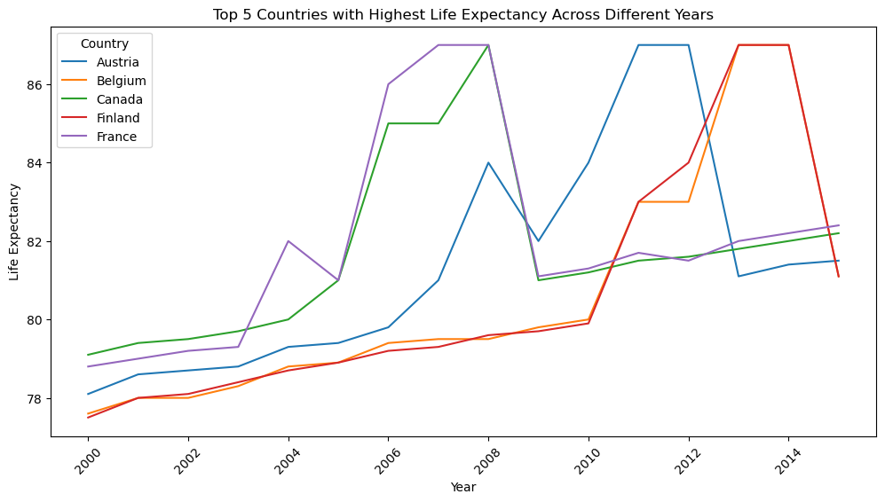

```python
top_n = 5  #  top N countries with the highest life expectancy
countries_with_top_life_expectancy = data.groupby('Country')['Life expectancy'].max().nlargest(top_n).index
data_filtered = data[data['Country'].isin(countries_with_top_life_expectancy)]

plt.figure(figsize=(12, 6))
sns.lineplot(x='Year', y='Life expectancy', hue='Country', data=data_filtered)
plt.title(f'Top {top_n} Countries with Highest Life Expectancy Across Different Years')
plt.xlabel('Year')
plt.ylabel('Life Expectancy')
plt.xticks(rotation=45)
plt.show()
```

**Line Chart**

The line chart shows that life expectancy has generally been increasing over the years in the five countries with the highest life expectancy. However, it's important to note that there are some ups and downs in the life expectancy values over time, even though the overall trend is upward.

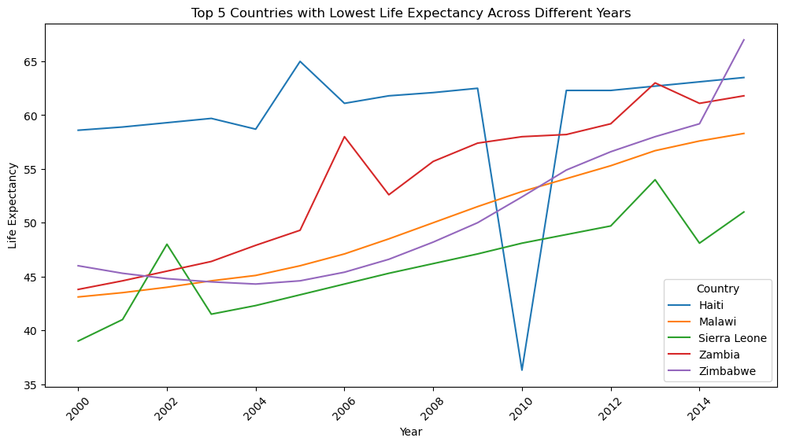

```python
top_n = 5  #  top N countries with the lowest life expectancy
countries_with_top_life_expectancy = data.groupby('Country')['Life expectancy'].min().nsmallest(top_n).index
data_filtered = data[data['Country'].isin(countries_with_top_life_expectancy)]

plt.figure(figsize=(12, 6))
sns.lineplot(x='Year', y='Life expectancy', hue='Country', data=data_filtered)
plt.title(f'Top {top_n} Countries with Lowest Life Expectancy Across Different Years')
plt.xlabel('Year')
plt.ylabel('Life Expectancy')
plt.xticks(rotation=45)
plt.show()
```

**Line Chart**

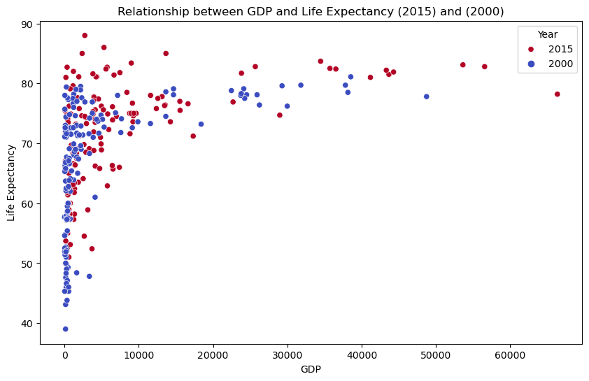

```python
latest_data = data[data['Year'] == data['Year'].max()]
earliest_data = data[data['Year'] == data['Year'].min()]
combined_data = pd.concat([latest_data,earliest_data])
plt.figure(figsize=(10, 6))
sns.scatterplot(x='GDP', y='Life expectancy', data=combined_data,hue='Year', palette= 'coolwarm')
plt.title(f'Relationship between GDP and Life Expectancy ({data["Year"].max()}) and ({data["Year"].min()})')
plt.xlabel('GDP')
plt.ylabel('Life Expectancy')
plt.legend(title='Year',loc='upper right', labels = [data['Year'].max(), data['Year'].min()])
plt.show()
```

**Scatter Plot**

```python
#!pip install package_name
#!pip install geopandas
#!pip install folium

#!pip install wget
!pip install plotly
!pip install pandas geopandas matplotlib
```

```
Looking in links: /usr/share/pip-wheels
Looking in links: /usr/share/pip-wheels
Looking in links: /usr/share/pip-wheels
Looking in links: /usr/share/pip-wheels
Looking in links: /usr/share/pip-wheels
Looking in links: /usr/share/pip-wheels
```

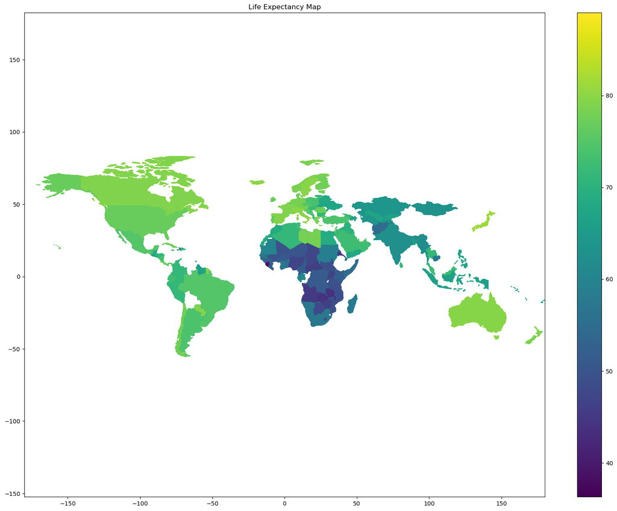

```python
import pandas as pd
import geopandas as gpd
import matplotlib.pyplot as plt

# Load the data from the CSV file
world = gpd.read_file("ne_110m_admin_0_countries.zip")

# Merge the data with the shapefile based on country names
merged_data = world.merge(data, left_on='ADMIN', right_on='Country', how='left')

# Plot the map with a larger figure size
plt.figure(figsize=(20, 15))  # Set a reasonable figsize for the map

# Adjust the aspect ratio and aspect mode to make the map larger
ax = plt.gca()
ax.set_aspect('auto')  # Set the aspect ratio to 'auto'
ax.set_adjustable('datalim')  # Set the aspect mode to 'datalim'

# Plot the choropleth map
merged_data.plot(column='Life expectancy', cmap='viridis', legend=True, ax=ax)
plt.title('Life Expectancy Map')

# Set the axis extent
ax.set_xlim([-180, 180])  # Longitude range (-180 to 180)
ax.set_ylim([-60, 90])    # Latitude range (-60 to 90)

plt.show()
```

**Choropleth map**

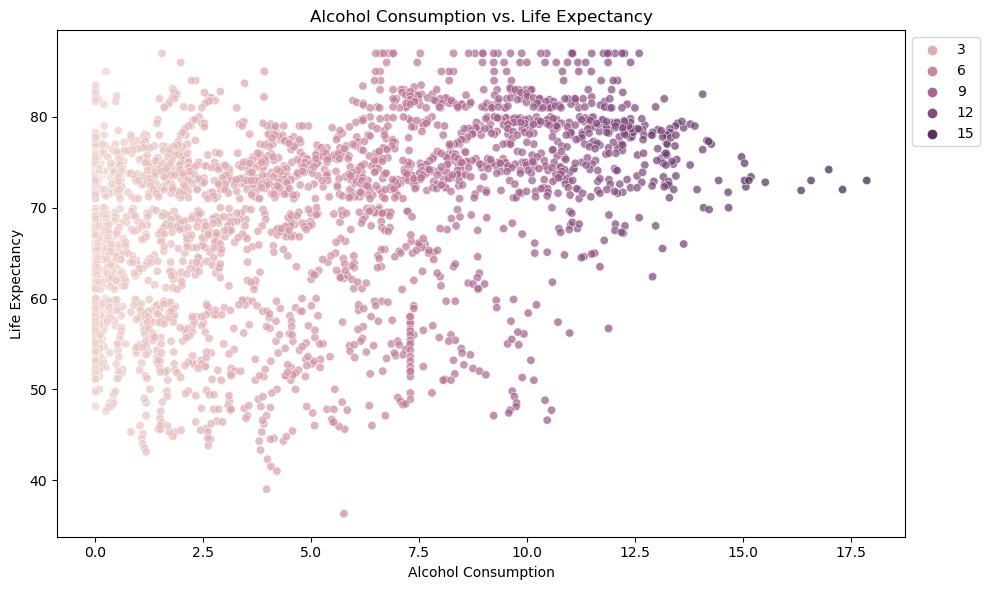

```python
data_filtered = data.dropna(subset=['Alcohol', 'Life expectancy'])

# Create a scatter plot to visualize the relationship
plt.figure(figsize=(10, 6))
sns.scatterplot(data=data_filtered, x='Alcohol', y='Life expectancy', hue='Alcohol', alpha=0.7)
plt.title('Alcohol Consumption vs. Life Expectancy')
plt.xlabel('Alcohol Consumption')
plt.ylabel('Life Expectancy')
plt.legend(loc='upper left', bbox_to_anchor=(1, 1))
plt.grid(False)
plt.tight_layout()
plt.show()
```

**Scatter Plot**

The scatter plot shows the relationship between alcohol consumption and life expectancy. Interestingly, there isn't a clear connection between them. For example, even when alcohol consumption is high, people can still live long lives. This suggests that alcohol consumption and life expectancy are not strongly linked.

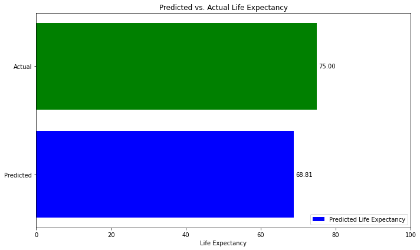

```python
import statsmodels.api as sm
import matplotlib.pyplot as plt
import pandas as pd

# Assuming you have loaded the 'data' DataFrame properly
# Assuming 'actual_life_expectancy' is the actual value you want to compare with

X = data[['Population', 'Hepatitis B', 'Measles', 'Polio', 'Diphtheria', 'HIV/AIDS', 'infant deaths', 'under-five deaths', 'Total expenditure', 'GDP', 'BMI', 'thinness  1-19 years', 'Alcohol', 'Schooling']]
y = data['Life expectancy']

# Add a constant term to the independent variables (required for the regression)
X = sm.add_constant(X)

# Fit the multiple regression model
model = sm.OLS(y, X).fit()

# Now, create the new_data DataFrame
new_data = {
    'const': 1,  # Add the constant term
    'Population': 20000000,
    'Hepatitis B': 75,
    'Measles': 1000,
    'Polio': 85,
    'Diphtheria': 85,
    'HIV/AIDS': 0.05,
    'infant deaths': 20,
    'under-five deaths': 40,
    'Total expenditure': 6.5,
    'GDP': 2000,
    'BMI': 25,
    'thinness  1-19 years': 3,
    'Alcohol': 5,
    'Schooling': 12,
}

# Create a DataFrame from the new_data dictionary
new_data_df = pd.DataFrame(new_data, index=[0])  # Assuming it's a single data point

# Make the prediction
predicted_life_expectancy = model.predict(new_data_df)



# Define the actual life expectancy for comparison
actual_life_expectancy = 75.0

# Create a horizontal bar plot for visualization
plt.figure(figsize=(10, 6))
bars = plt.barh(['Predicted', 'Actual'], [predicted_life_expectancy[0], actual_life_expectancy], color=['blue', 'green'])
plt.xlabel('Life Expectancy')
plt.title('Predicted vs. Actual Life Expectancy')
plt.xlim(0, 100)  # Adjust the x-axis limits if needed

# Add numerical labels above the bars
for bar in bars:
    plt.text(bar.get_width() + 0.5, bar.get_y() + bar.get_height() / 2, f'{bar.get_width():.2f}', va='center', color='black')

plt.legend(['Predicted Life Expectancy', 'Actual Life Expectancy'])
plt.tight_layout()
plt.show()
```

**Horizontal bar plot**

The plot compares the predicted life expectancy with the actual life expectancy using a horizontal bar chart.

Here’s how the prediction was made:

```
Population: 20,000,000
Hepatitis B Vaccination Rate: 75%
Measles Cases: 1,000
Polio Vaccination Rate: 85%
Diphtheria Vaccination Rate: 85%
HIV/AIDS Rate: 0.05%
Infant Deaths: 20
Under-Five Deaths: 40
Total Expenditure on Health: 6.5%
GDP: $2,000
BMI: 25
Thinness in Ages 1-19: 3%
Alcohol Consumption: 5 liters
Schooling Years: 12
```

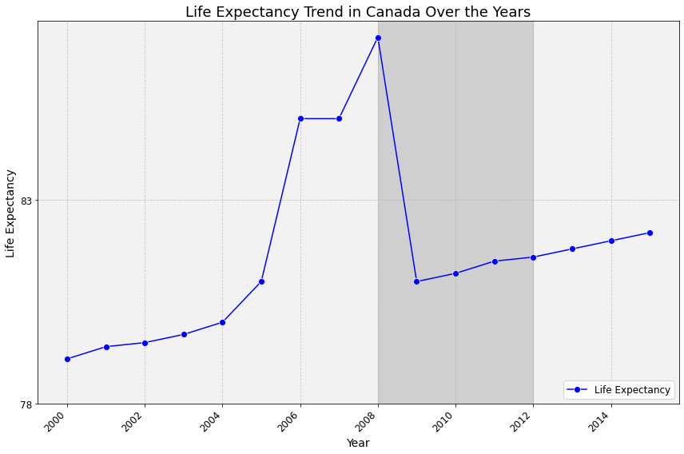

```python
import matplotlib.pyplot as plt
import seaborn as sns

# Assuming you have already loaded and filtered your data
Canada_data = data[data['Country'] == 'Canada']

# Set up the figure and axes
plt.figure(figsize=(12, 8))
ax = sns.lineplot(x='Year', y='Life expectancy', data=Canada_data, marker='o', markersize=8, color='b')

# Adding a grid for better readability
ax.grid(True, linestyle='--', alpha=0.7)

# Adding a background color to the plot
ax.set_facecolor('#f2f2f2')

# Adding a title and adjusting font size
plt.title('Life Expectancy Trend in Canada Over the Years', fontsize=18)

# Adding labels and adjusting font size
plt.xlabel('Year', fontsize=14)
plt.ylabel('Life Expectancy', fontsize=14)

# Adding custom x-axis ticks for better readability
plt.xticks(rotation=45, ha='right', fontsize=12)

# Adding custom y-axis ticks with 5-year intervals
plt.yticks(range(int(min(Canada_data['Life expectancy'])) - 1, int(max(Canada_data['Life expectancy'])) + 1, 5), fontsize=12)

# Adding a legend
plt.legend(['Life Expectancy'], loc='lower right', fontsize=12)

# Adding a shaded region to highlight a specific period, if applicable
plt.axvspan(2008, 2012, color='gray', alpha=0.3)

# Display the plot
plt.tight_layout()
plt.show()
```

**Line Chart**

The line chart shows that life expectancy in Canada increased steadily until 2008. However, there was a sharp drop in life expectancy from 87 years in 2008 to 81 years in 2009.

```python
# Filter the data for Canada and the years 2008 and 2009
canada_data_2008 = Canada_data[Canada_data['Year'] == 2008]
canada_data_2009 = Canada_data[Canada_data['Year'] == 2009]

# Calculate the average life expectancy for 2008 and 2009
average_life_expectancy_2008 = canada_data_2008['Life expectancy'].mean()
average_life_expectancy_2009 = canada_data_2009['Life expectancy'].mean()

print("Average Life Expectancy in 2008:", average_life_expectancy_2008)
print("Average Life Expectancy in 2009:", average_life_expectancy_2009)

# Calculate the average GDP for 2008 and 2009
average_gdp_2008 = canada_data_2008['GDP'].mean()
average_gdp_2009 = canada_data_2009['GDP'].mean()

print("Average GDP in 2008:", average_gdp_2008)
print("Average GDP in 2009:", average_gdp_2009)

# Calculate the average Total Expenditure on healthcare for 2008 and 2009
average_total_expenditure_2008 = canada_data_2008['Total expenditure'].mean()
average_total_expenditure_2009 = canada_data_2009['Total expenditure'].mean()


# Calculate the average Alcohol consumption for 2008 and 2009
average_alcohol_consumption_2008 = canada_data_2008['Alcohol'].mean()
average_alcohol_consumption_2009 = canada_data_2009['Alcohol'].mean()

print("Average Alcohol Consumption in 2008:", average_alcohol_consumption_2008)
print("Average Alcohol Consumption in 2009:", average_alcohol_consumption_2009)
```

```
Average Life Expectancy in 2008: 87.0
Average Life Expectancy in 2009: 81.0
Average GDP in 2008: 46596.33599
Average GDP in 2009: 4773.45436
Average Alcohol Consumption in 2008: 8.3
Average Alcohol Consumption in 2009: 8.4
```

**Summary of Key Metrics**

Average Life Expectancy:

```
In 2008: 87.0 years
In 2009: 81.0 years
Average GDP:

In 2008: $46,596.34
In 2009: $4,773.45
Average Alcohol Consumption:

In 2008: 8.3 liters
In 2009: 8.4 liters
```

These figures highlight a significant drop in life expectancy from 2008 to 2009, while GDP decreased sharply, and alcohol consumption remained relatively stable.